# Visualisation Practice Exercise

# Import libraries & Iris data

```r
library(ggplot2)
library(ggcorrplot)
library(tidyverse)
library(plotly)
library(reshape2)
data(iris)
summary(iris)
```

```
  Sepal.Length    Sepal.Width     Petal.Length    Petal.Width          Species
 Min.   :4.300   Min.   :2.000   Min.   :1.000   Min.   :0.100   setosa    :50
 1st Qu.:5.100   1st Qu.:2.800   1st Qu.:1.600   1st Qu.:0.300   versicolor:50
 Median :5.800   Median :3.000   Median :4.350   Median :1.300   virginica :50
 Mean   :5.843   Mean   :3.057   Mean   :3.758   Mean   :1.199
 3rd Qu.:6.400   3rd Qu.:3.300   3rd Qu.:5.100   3rd Qu.:1.800
 Max.   :7.900   Max.   :4.400   Max.   :6.900   Max.   :2.500
```

# 1. Scatter Plot

```r
petal_sizes <- plot_ly(data = iris, x = ~Petal.Width, y = ~Petal.Length, color = ~Species, type = 'scatter', mode = 'markers')
petal_sizes
```

I have started with a basic scatter plot to get a quick and clear understanding of difference in petal sizes between the different species of Iris.

# 2. Circular histogram

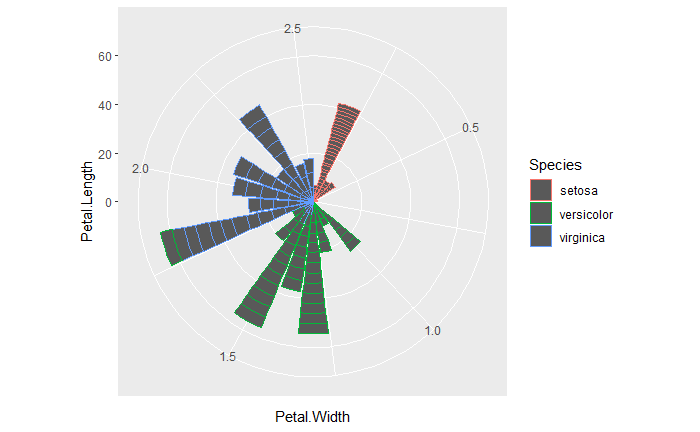

```r
ggplot(petal_sizes, aes(x = Petal.Width, y= Petal.Length, col = Species)) + geom_bar(stat='identity') + coord_polar()
```

# 3. Bubble scatter plot

```r
iris$Petal.Size <- (iris$Petal.Length*iris$Petal.Width)
max_marker_size <- 40
data <- iris
sizeref <- 2.0 * max(iris$Petal.Size) / (max_marker_size**2)
petals <- plot_ly(data, x = ~Petal.Width, y = ~Petal.Length, text = ~Species, type = 'scatter', mode = 'markers', color = ~Species, colors = 'Paired', sizes = c(10, 50),
        marker = list(size = ~Petal.Size, opacity = 0.5, sizemode = 'area', sizeref = sizeref)) %>%
  layout(title = 'Petal Sizes by Species',
         xaxis = list(showgrid = T),
         yaxis = list(showgrid = T),
         showlegend = T)
petals
```

The bubble scatter plot shows similar information to the standard scatter plot, with a bit more clarity on the size comparison between the species. The bubbles refer to the Petal.Size attribute. This is calculated by multiplying the width by the length of the petal. This will give you a general idea of how large one petal is compared to another.

# 4.Dumbbell plot

```r
min_setosa_swidth <- min(iris$Sepal.Width[iris$Species == "setosa"])
max_setosa_swidth <- max(iris$Sepal.Width[iris$Species == "setosa"])
min_versicolor_swidth <- min(iris$Sepal.Width[iris$Species == "versicolor"])
max_versicolor_swidth <- max(iris$Sepal.Width[iris$Species == "versicolor"])
min_virginica_swidth <- min(iris$Sepal.Width[iris$Species == "virginica"])
max_virginica_swidth <- max(iris$Sepal.Width[iris$Species == "virginica"])
sepal_widths <- data.frame(Species = unique(iris$Species), min_width = c(min_setosa_swidth, min_versicolor_swidth, min_virginica_swidth), max_width =
                             c(max_setosa_swidth, max_versicolor_swidth, max_virginica_swidth))
sepal_widths
```

```
     Species min_width max_width
1     setosa       2.3       4.4
2 versicolor       2.0       3.4
3  virginica       2.2       3.8
```

I started by setting up a new data frame to show the ranges for each specie to make the plotting stage easier.

```r
sepal_sizes <- plot_ly(sepal_widths, color = I("gray80")) %>%
  add_segments(x = ~min_width, xend = ~max_width, y = ~Species, yend = ~Species, showlegend = FALSE) %>%
  add_markers(x = ~min_width, y = ~Species, name = "min_width", color = I("green")) %>%
  add_markers(x = ~max_width, y = ~Species, name = "max_width", color = I("blue")) %>%
  layout(
    title = "Iris Species Sepal Width",
    xaxis = list(title = "Sepal Width"),
    margin = list(l = 65)
  )
sepal_sizes
```

The dumbbell plot shows the extremities of each specie, this gives you an idea of the different ranges that each specie can have and clearly comparable between them.

# 5. Stacked barcharts

```r
mean_setosa_petal_length <- mean(iris$Petal.Length[iris$Species == "setosa"])
mean_setosa_sepal_length <- mean(iris$Sepal.Length[iris$Species == "setosa"])
mean_versicolor_petal_length <- mean(iris$Petal.Length[iris$Species == "versicolor"])
mean_versicolor_sepal_length <- mean(iris$Sepal.Length[iris$Species == "versicolor"])
mean_virginica_petal_length <- mean(iris$Petal.Length[iris$Species == "virginica"])
mean_virginica_sepal_length <- mean(iris$Sepal.Length[iris$Species == "virginica"])
average_lengths <- data.frame(Species = unique(iris$Species), mean_petal_length = c(mean_setosa_petal_length, mean_versicolor_petal_length, mean_virginica_petal_length), mean_sepal_length = c(mean_setosa_sepal_length, mean_versicolor_sepal_length, mean_virginica_sepal_length))
average_lengths
```

```
     Species mean_petal_length mean_sepal_length
1     setosa             1.462             5.006
2 versicolor             4.260             5.936
3  virginica             5.552             6.588
```

Like with the dumbbell plot creating a new data frame with the mean lengths for the species makes plotting the bar charts simpler.

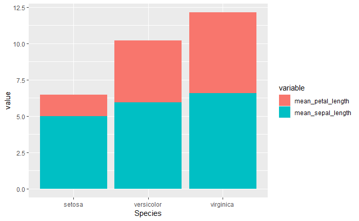

```r
melted_data <- melt(average_lengths, id.vars = "Species")
ggplot(melted_data, aes(x = Species, y = value, fill = variable))+
  geom_bar(stat = "identity")
```

The stacked bar chart shows a comparison of the petal length and the sepal length and makes it easy to compare these to the other species.